# Card (1995) — Outcome Weights & Kappa Estimators

College Proximity Instrument: SUW Table 3 Replication + Translation Invariance

Alexander Unger

09 June 2026

# Setup

## Packages & Functions

```r
library(haven)
library(AER)
library(sandwich)
library(lmtest)
library(knitr)
library(kableExtra)

# All estimators, analytical SEs, weight diagnostics — sourced from the shared
# library. Identical functions to the Vietnam (Angrist 1990) replication.
source("functions_all.R")
cat("functions_all.R sourced.\n")
```

```
## functions_all.R sourced.
```

## Data & Design

**Setting.** Card (1995) NLSYM subsample (N = 3,010). Instrument Z = `nearc4` (grew up near a 4-year college). Two binary treatments: **somecol** = 1{educ > 12} (some college) and **educ16** = 1{educ ≥ 16} (college completion). Outcome: log wages in two units (dollars / cents) to test translation invariance. Two covariate specifications: **Card** (exper, expersq, black, south, smsa, smsa66, reg661–668) and **Kitagawa** (black, south, smsa, smsa66, south66).

```r
data_path  <- "/Users/alexung/Desktop/master_thesis/code/"
card       <- read_dta(file.path(data_path, "card.dta"))

# Sample restriction: N = 3,010
card_clean <- card[!is.na(card$wage) & !is.na(card$educ), ]

# Outcomes in two units: lwage_cnt = lwage + log(100)
card_clean$lwage_cnt <- log(card_clean$wage)         # cents
card_clean$lwage     <- log(card_clean$wage / 100)   # dollars

# Binary treatments
card_clean$somecol <- as.integer(card_clean$educ > 12)
card_clean$educ16  <- as.integer(card_clean$educ >= 16)

# Instrument
card_clean$Z_inst <- as.integer(card_clean$nearc4)

# expersq if missing
if (!"expersq" %in% names(card_clean)) {
  card_clean$expersq <- card_clean$exper^2
}

cat(sprintf("N = %d (should be 3,010)\n", nrow(card_clean)))
```

```
## N = 3010 (should be 3,010)
```

```r
cat(sprintf("somecol mean = %.4f | educ16 mean = %.4f | nearc4 mean = %.4f\n",
            mean(card_clean$somecol), mean(card_clean$educ16),
            mean(card_clean$Z_inst)))
```

```
## somecol mean = 0.5053 | educ16 mean = 0.2714 | nearc4 mean = 0.6821
```

```r
# Card spec — WITH intercept (for logit/CBPS)
X_card_kappa <- model.matrix(
  ~ exper + expersq + black + south + smsa + smsa66 +
    reg661 + reg662 + reg663 + reg664 + reg665 + reg666 + reg667 + reg668,
  data = card_clean
)
X_card_df <- as.data.frame(X_card_kappa[, -1, drop = FALSE])

# Kitagawa spec — WITH intercept
X_kit_kappa <- model.matrix(
  ~ black + south + smsa + smsa66 + south66,
  data = card_clean
)
X_kit_df <- as.data.frame(X_kit_kappa[, -1, drop = FALSE])

# Core vectors
Y_cnt <- card_clean$lwage_cnt
Y_dol <- card_clean$lwage
Z     <- card_clean$Z_inst
D1    <- card_clean$somecol   # treatment 1: some college
D2    <- card_clean$educ16    # treatment 2: college completion
k     <- log(100)

cat(sprintf("Card spec: %d covariates | Kitagawa spec: %d covariates\n",
            ncol(X_card_kappa) - 1, ncol(X_kit_kappa) - 1))
```

```
## Card spec: 14 covariates | Kitagawa spec: 5 covariates
```

# Part I — SUW Table 3 Replication

**Layout.** SUW Table 3 has 8 columns: 2 treatments × 2 specifications × 2 outcome units. To keep things readable, results are split into **two tabs by treatment** (somecol / educ16). Within each tab, the four columns are spec × outcome unit. Normalized estimators (τ_cb_u, τ_ml_u, τ_ml_a10) are translation invariant — their cents and dollars columns should match. Unnormalized estimators (τ_ml_a, τ_ml_t, τ_ml_a0) are not.

```r
# Run one full column: 2SLS + all six kappa estimators with analytical SEs
run_card_column <- function(Y, D, X_kappa, X_df) {
  list(
    tsls  = run_2sls(Y, D, Z, X_df, endog_name = "D"),
    kappa = kappa_analytic_se_all(Y, Z, D, X_kappa)
  )
}

# Treatment 1: somecol (cols 1-4)
col1 <- run_card_column(Y_cnt, D1, X_card_kappa, X_card_df)  # cents, Card
col2 <- run_card_column(Y_dol, D1, X_card_kappa, X_card_df)  # dollars, Card
col3 <- run_card_column(Y_cnt, D1, X_kit_kappa,  X_kit_df)   # cents, Kitagawa
col4 <- run_card_column(Y_dol, D1, X_kit_kappa,  X_kit_df)   # dollars, Kitagawa

# Treatment 2: educ16 (cols 5-8)
col5 <- run_card_column(Y_cnt, D2, X_card_kappa, X_card_df)  # cents, Card
col6 <- run_card_column(Y_dol, D2, X_card_kappa, X_card_df)  # dollars, Card
col7 <- run_card_column(Y_cnt, D2, X_kit_kappa,  X_kit_df)   # cents, Kitagawa
col8 <- run_card_column(Y_dol, D2, X_kit_kappa,  X_kit_df)   # dollars, Kitagawa

cat("All 8 columns computed.\n")
```

```
## All 8 columns computed.
```

## Results

### Treatment: Some College (educ > 12)

```r
tbl_d1 <- build_treatment_table(col1, col2, col3, col4)

tbl_d1 %>%
  kbl(escape = FALSE, align = c("l","c","c","c","c"),
      caption = "SUW Table 3 — Treatment: somecol (educ > 12). Effect of some college on log wages.") %>%
  kable_styling(bootstrap_options = c("striped","hover","condensed"),
                full_width = TRUE, font_size = 13) %>%
  pack_rows("Panel A: 2SLS (HC1-robust)",          1, 1) %>%
  pack_rows("Panel B: Normalized kappa estimators", 2, 4) %>%
  pack_rows("Panel C: Unnormalized kappa estimators",5, 7) %>%
  row_spec(2:4, background = "#eef6ff") %>%
  row_spec(5:7, background = "#fffbf0") %>%
  footnote(general = "Each cell: estimate (SE below). Blue = normalized (translation invariant). Orange = unnormalized. Card spec: exper, expersq, black, south, smsa, smsa66, reg661–668. Kitagawa spec: black, south, smsa, smsa66, south66. Stars: * p<0.10, ** p<0.05, *** p<0.01.")
```

SUW Table 3 — Treatment: somecol (educ > 12). Effect of some college on log wages.

| Estimator | Card / cents | Card / dollars | Kitagawa / cents | Kitagawa / dollars |
| --- | --- | --- | --- | --- |
| **Panel A: 2SLS (HC1-robust)** |  |  |  |  |
| 2SLS | 0.661** (0.295) | 0.661** (0.295) | 0.575* (0.308) | 0.575* (0.308) |
| **Panel B: Normalized kappa estimators** |  |  |  |  |
| τ_cb_u | 0.376* (0.223) | 0.376* (0.223) | 0.331 (0.236) | 0.331 (0.236) |
| τ_ml_u | 0.331 (0.202) | 0.331 (0.202) | 0.356 (0.244) | 0.356 (0.244) |
| τ_ml_a10 | 0.346* (0.200) | 0.346* (0.200) | 0.293 (0.252) | 0.293 (0.252) |
| **Panel C: Unnormalized kappa estimators** |  |  |  |  |
| τ_ml_a | -0.319 (1.182) | 0.170 (0.370) | 2.248** (0.971) | 0.842** (0.362) |
| τ_ml_t | -0.321 (1.201) | 0.171 (0.367) | 2.053** (0.813) | 0.769** (0.308) |
| τ_ml_a0 | -0.290 (1.036) | 0.154 (0.354) | 2.846* (1.592) | 1.066* (0.574) |

Note:  
Each cell: estimate (SE below). Blue = normalized (translation invariant). Orange = unnormalized. Card spec: exper, expersq, black, south, smsa, smsa66, reg661–668. Kitagawa spec: black, south, smsa, smsa66, south66. Stars: * p<0.10, ** p<0.05, *** p<0.01.

### Treatment: College Completion (educ ≥ 16)

```r
tbl_d2 <- build_treatment_table(col5, col6, col7, col8)

tbl_d2 %>%
  kbl(escape = FALSE, align = c("l","c","c","c","c"),
      caption = "SUW Table 3 — Treatment: educ16 (educ ≥ 16). Effect of college completion on log wages.") %>%
  kable_styling(bootstrap_options = c("striped","hover","condensed"),
                full_width = TRUE, font_size = 13) %>%
  pack_rows("Panel A: 2SLS (HC1-robust)",          1, 1) %>%
  pack_rows("Panel B: Normalized kappa estimators", 2, 4) %>%
  pack_rows("Panel C: Unnormalized kappa estimators",5, 7) %>%
  row_spec(2:4, background = "#eef6ff") %>%
  row_spec(5:7, background = "#fffbf0") %>%
  footnote(general = "Each cell: estimate (SE below). Blue = normalized (translation invariant). Orange = unnormalized. Stars: * p<0.10, ** p<0.05, *** p<0.01.")
```

SUW Table 3 — Treatment: educ16 (educ ≥ 16). Effect of college completion on log wages.

| Estimator | Card / cents | Card / dollars | Kitagawa / cents | Kitagawa / dollars |
| --- | --- | --- | --- | --- |
| **Panel A: 2SLS (HC1-robust)** |  |  |  |  |
| 2SLS | 1.392* (0.801) | 1.392* (0.801) | 0.991 (0.611) | 0.991 (0.611) |
| **Panel B: Normalized kappa estimators** |  |  |  |  |
| τ_cb_u | 0.853 (0.549) | 0.853 (0.549) | 0.588 (0.433) | 0.588 (0.433) |
| τ_ml_u | 0.619 (0.387) | 0.619 (0.387) | 0.628 (0.448) | 0.628 (0.448) |
| τ_ml_a10 | 0.586* (0.356) | 0.586* (0.356) | 0.836 (0.821) | 0.836 (0.821) |
| **Panel C: Unnormalized kappa estimators** |  |  |  |  |
| τ_ml_a | -0.594 (2.184) | 0.315 (0.696) | 4.317* (2.485) | 1.617* (0.891) |
| τ_ml_t | -0.601 (2.251) | 0.319 (0.687) | 3.651** (1.780) | 1.367** (0.648) |
| τ_ml_a0 | -0.501 (1.728) | 0.266 (0.639) | 7.241 (7.246) | 2.712 (2.577) |

Note:  
Each cell: estimate (SE below). Blue = normalized (translation invariant). Orange = unnormalized. Stars: * p<0.10, ** p<0.05, *** p<0.01.

# Part II — Translation Invariance Check

## By Treatment & Specification

### somecol — Card

```r
style_ti(build_ti_table(D1, X_card_kappa),
         "Translation Invariance — somecol, Card spec")
```

Translation Invariance — somecol, Card spec

| Estimator | Dollars | Cents | Diff_actual | Diff_pred | Match |
| --- | --- | --- | --- | --- | --- |
| τ_cb_u | 0.3762 | 0.3762 | 0.000000 | 0.000000 | TRUE |
| τ_ml_u | 0.3308 | 0.3308 | 0.000000 | 0.000000 | TRUE |
| τ_ml_a10 | 0.3460 | 0.3460 | 0.000000 | 0.000000 | TRUE |
| τ_ml_a | 0.1695 | -0.3193 | -0.488839 | -0.488839 | TRUE |
| τ_ml_t | 0.1707 | -0.3214 | -0.492106 | -0.492106 | TRUE |
| τ_ml_a0 | 0.1542 | -0.2904 | -0.444597 | -0.444597 | TRUE |

Note:  
Diff_actual = Cents − Dollars. Diff_pred = Σωᵢ × log(100). Green = translation invariant.

### somecol — Kitagawa

```r
style_ti(build_ti_table(D1, X_kit_kappa),
         "Translation Invariance — somecol, Kitagawa spec")
```

Translation Invariance — somecol, Kitagawa spec

| Estimator | Dollars | Cents | Diff_actual | Diff_pred | Match |
| --- | --- | --- | --- | --- | --- |
| τ_cb_u | 0.3310 | 0.3310 | 0.000000 | 0.000000 | TRUE |
| τ_ml_u | 0.3556 | 0.3556 | 0.000000 | 0.000000 | TRUE |
| τ_ml_a10 | 0.2930 | 0.2930 | 0.000000 | 0.000000 | TRUE |
| τ_ml_a | 0.8418 | 2.2476 | 1.405803 | 1.405803 | TRUE |
| τ_ml_t | 0.7688 | 2.0526 | 1.283819 | 1.283819 | TRUE |
| τ_ml_a0 | 1.0659 | 2.8460 | 1.780059 | 1.780059 | TRUE |

Note:  
Diff_actual = Cents − Dollars. Diff_pred = Σωᵢ × log(100). Green = translation invariant.

### educ16 — Card

```r
style_ti(build_ti_table(D2, X_card_kappa),
         "Translation Invariance — educ16, Card spec")
```

Translation Invariance — educ16, Card spec

| Estimator | Dollars | Cents | Diff_actual | Diff_pred | Match |
| --- | --- | --- | --- | --- | --- |
| τ_cb_u | 0.8530 | 0.8530 | 0.000000 | 0.000000 | TRUE |
| τ_ml_u | 0.6191 | 0.6191 | 0.000000 | 0.000000 | TRUE |
| τ_ml_a10 | 0.5862 | 0.5862 | 0.000000 | 0.000000 | TRUE |
| τ_ml_a | 0.3154 | -0.5939 | -0.909273 | -0.909273 | TRUE |
| τ_ml_t | 0.3193 | -0.6013 | -0.920642 | -0.920642 | TRUE |
| τ_ml_a0 | 0.2661 | -0.5012 | -0.767256 | -0.767256 | TRUE |

Note:  
Diff_actual = Cents − Dollars. Diff_pred = Σωᵢ × log(100). Green = translation invariant.

### educ16 — Kitagawa

```r
style_ti(build_ti_table(D2, X_kit_kappa),
         "Translation Invariance — educ16, Kitagawa spec")
```

Translation Invariance — educ16, Kitagawa spec

| Estimator | Dollars | Cents | Diff_actual | Diff_pred | Match |
| --- | --- | --- | --- | --- | --- |
| τ_cb_u | 0.5885 | 0.5885 | 0.000000 | 0.000000 | TRUE |
| τ_ml_u | 0.6276 | 0.6276 | 0.000000 | 0.000000 | TRUE |
| τ_ml_a10 | 0.8356 | 0.8356 | 0.000000 | 0.000000 | TRUE |
| τ_ml_a | 1.6168 | 4.3169 | 2.700096 | 2.700096 | TRUE |
| τ_ml_t | 1.3673 | 3.6507 | 2.283386 | 2.283386 | TRUE |
| τ_ml_a0 | 2.7120 | 7.2410 | 4.529008 | 4.529008 | TRUE |

Note:  
Diff_actual = Cents − Dollars. Diff_pred = Σωᵢ × log(100). Green = translation invariant.

# Part III — Weight Diagnostics

## By Treatment & Specification

### somecol — Card

```r
style_diag(build_diag_table(D1, X_card_kappa),
           "Weight Diagnostics — somecol, Card spec")
```

Weight Diagnostics — somecol, Card spec

| Estimator | Sum_w | ESS | Pct_neg | Max_abs_w |
| --- | --- | --- | --- | --- |
| τ_cb_u (CBPS, norm) | 0.0000000 | 3 | 31.8 | 0.086905 |
| τ_ml_u (MLE, norm) | 0.0000000 | 4 | 31.8 | 0.051920 |
| τ_ml_a10 (MLE, norm) | 0.0000000 | 4 | 31.8 | 0.054816 |
| τ_ml_a (unnorm) | -0.1061501 | 3 | 31.8 | 0.054452 |
| τ_ml_t (unnorm) | -0.1068595 | 3 | 31.8 | 0.054816 |
| τ_ml_a0 (unnorm) | -0.0965429 | 4 | 31.8 | 0.049524 |

Note:  
Sum_w ≈ 0 ⟺ translation invariant. ESS = 1/Σωᵢ². Low ESS = extreme weight concentration.

### somecol — Kitagawa

```r
style_diag(build_diag_table(D1, X_kit_kappa),
           "Weight Diagnostics — somecol, Kitagawa spec")
```

Weight Diagnostics — somecol, Kitagawa spec

| Estimator | Sum_w | ESS | Pct_neg | Max_abs_w |
| --- | --- | --- | --- | --- |
| τ_cb_u (CBPS, norm) | 0.0000000 | 3 | 31.8 | 0.045670 |
| τ_ml_u (MLE, norm) | 0.0000000 | 3 | 31.8 | 0.044385 |
| τ_ml_a10 (MLE, norm) | 0.0000000 | 3 | 31.8 | 0.052601 |
| τ_ml_a (unnorm) | 0.3052662 | 3 | 31.8 | 0.041541 |
| τ_ml_t (unnorm) | 0.2787776 | 4 | 31.8 | 0.037937 |
| τ_ml_a0 (unnorm) | 0.3865350 | 2 | 31.8 | 0.052601 |

Note:  
Sum_w ≈ 0 ⟺ translation invariant. ESS = 1/Σωᵢ². Low ESS = extreme weight concentration.

### educ16 — Card

```r
style_diag(build_diag_table(D2, X_card_kappa),
           "Weight Diagnostics — educ16, Card spec")
```

Weight Diagnostics — educ16, Card spec

| Estimator | Sum_w | ESS | Pct_neg | Max_abs_w |
| --- | --- | --- | --- | --- |
| τ_cb_u (CBPS, norm) | 0.0000000 | 1 | 31.8 | 0.197058 |
| τ_ml_u (MLE, norm) | 0.0000000 | 1 | 31.8 | 0.097168 |
| τ_ml_a10 (MLE, norm) | 0.0000000 | 1 | 31.8 | 0.102551 |
| τ_ml_a (unnorm) | -0.1974461 | 1 | 31.8 | 0.101285 |
| τ_ml_t (unnorm) | -0.1999148 | 1 | 31.8 | 0.102551 |
| τ_ml_a0 (unnorm) | -0.1666075 | 1 | 31.8 | 0.085466 |

Note:  
Sum_w ≈ 0 ⟺ translation invariant. ESS = 1/Σωᵢ². Low ESS = extreme weight concentration.

### educ16 — Kitagawa

```r
style_diag(build_diag_table(D2, X_kit_kappa),
           "Weight Diagnostics — educ16, Kitagawa spec")
```

Weight Diagnostics — educ16, Kitagawa spec

| Estimator | Sum_w | ESS | Pct_neg | Max_abs_w |
| --- | --- | --- | --- | --- |
| τ_cb_u (CBPS, norm) | 0.0000000 | 1 | 31.8 | 0.081202 |
| τ_ml_u (MLE, norm) | 0.0000000 | 1 | 31.8 | 0.078334 |
| τ_ml_a10 (MLE, norm) | 0.0000000 | 0 | 31.8 | 0.133832 |
| τ_ml_a (unnorm) | 0.5863184 | 1 | 31.8 | 0.079788 |
| τ_ml_t (unnorm) | 0.4958309 | 1 | 31.8 | 0.067474 |
| τ_ml_a0 (unnorm) | 0.9834616 | 0 | 31.8 | 0.133832 |

Note:  
Sum_w ≈ 0 ⟺ translation invariant. ESS = 1/Σωᵢ². Low ESS = extreme weight concentration.

### Combined Overview

```r
combine_diag <- function() {
  cells <- list(
    list(D1, X_card_kappa, "somecol", "Card"),
    list(D1, X_kit_kappa,  "somecol", "Kitagawa"),
    list(D2, X_card_kappa, "educ16",  "Card"),
    list(D2, X_kit_kappa,  "educ16",  "Kitagawa")
  )
  out <- list()
  for (c in cells) {
    d <- build_diag_table(c[[1]], c[[2]])
    d$Treatment <- c[[3]]
    d$Spec      <- c[[4]]
    out[[length(out)+1]] <- d
  }
  res <- do.call(rbind, out)
  res[, c("Treatment","Spec","Estimator","Sum_w","ESS","Pct_neg","Max_abs_w")]
}

comb <- combine_diag()
comb %>%
  kbl(caption = "Weight Diagnostics — All 4 Cells (ESS focus)",
      align = c("l","l","l","r","r","r","r")) %>%
  kable_styling(bootstrap_options = c("striped","hover","condensed"),
                full_width = TRUE, font_size = 12) %>%
  pack_rows("somecol — Card",      1, 6) %>%
  pack_rows("somecol — Kitagawa",  7, 12) %>%
  pack_rows("educ16 — Card",       13, 18) %>%
  pack_rows("educ16 — Kitagawa",   19, 24) %>%
  footnote(general = "Note the low ESS in the Kitagawa cells — a key discussion point: weak instrument destabilizes the kappa weights.")
```

Weight Diagnostics — All 4 Cells (ESS focus)

| Treatment | Spec | Estimator | Sum_w | ESS | Pct_neg | Max_abs_w |
| --- | --- | --- | --- | --- | --- | --- |
| **somecol — Card** |  |  |  |  |  |  |
| somecol | Card | τ_cb_u (CBPS, norm) | 0.0000000 | 3 | 31.8 | 0.086905 |
| somecol | Card | τ_ml_u (MLE, norm) | 0.0000000 | 4 | 31.8 | 0.051920 |
| somecol | Card | τ_ml_a10 (MLE, norm) | 0.0000000 | 4 | 31.8 | 0.054816 |
| somecol | Card | τ_ml_a (unnorm) | -0.1061501 | 3 | 31.8 | 0.054452 |
| somecol | Card | τ_ml_t (unnorm) | -0.1068595 | 3 | 31.8 | 0.054816 |
| somecol | Card | τ_ml_a0 (unnorm) | -0.0965429 | 4 | 31.8 | 0.049524 |
| **somecol — Kitagawa** |  |  |  |  |  |  |
| somecol | Kitagawa | τ_cb_u (CBPS, norm) | 0.0000000 | 3 | 31.8 | 0.045670 |
| somecol | Kitagawa | τ_ml_u (MLE, norm) | 0.0000000 | 3 | 31.8 | 0.044385 |
| somecol | Kitagawa | τ_ml_a10 (MLE, norm) | 0.0000000 | 3 | 31.8 | 0.052601 |
| somecol | Kitagawa | τ_ml_a (unnorm) | 0.3052662 | 3 | 31.8 | 0.041541 |
| somecol | Kitagawa | τ_ml_t (unnorm) | 0.2787776 | 4 | 31.8 | 0.037937 |
| somecol | Kitagawa | τ_ml_a0 (unnorm) | 0.3865350 | 2 | 31.8 | 0.052601 |
| **educ16 — Card** |  |  |  |  |  |  |
| educ16 | Card | τ_cb_u (CBPS, norm) | 0.0000000 | 1 | 31.8 | 0.197058 |
| educ16 | Card | τ_ml_u (MLE, norm) | 0.0000000 | 1 | 31.8 | 0.097168 |
| educ16 | Card | τ_ml_a10 (MLE, norm) | 0.0000000 | 1 | 31.8 | 0.102551 |
| educ16 | Card | τ_ml_a (unnorm) | -0.1974461 | 1 | 31.8 | 0.101285 |
| educ16 | Card | τ_ml_t (unnorm) | -0.1999148 | 1 | 31.8 | 0.102551 |
| educ16 | Card | τ_ml_a0 (unnorm) | -0.1666075 | 1 | 31.8 | 0.085466 |
| **educ16 — Kitagawa** |  |  |  |  |  |  |
| educ16 | Kitagawa | τ_cb_u (CBPS, norm) | 0.0000000 | 1 | 31.8 | 0.081202 |
| educ16 | Kitagawa | τ_ml_u (MLE, norm) | 0.0000000 | 1 | 31.8 | 0.078334 |
| educ16 | Kitagawa | τ_ml_a10 (MLE, norm) | 0.0000000 | 0 | 31.8 | 0.133832 |
| educ16 | Kitagawa | τ_ml_a (unnorm) | 0.5863184 | 1 | 31.8 | 0.079788 |
| educ16 | Kitagawa | τ_ml_t (unnorm) | 0.4958309 | 1 | 31.8 | 0.067474 |
| educ16 | Kitagawa | τ_ml_a0 (unnorm) | 0.9834616 | 0 | 31.8 | 0.133832 |

# Part IV — Algebraic Identity Check

**Sanity check.** Every kappa estimator satisfies $\sum_i \omega_i Y_i = \hat\tau$ to machine precision. If any check fails, the weight construction is wrong. All should read TRUE.

```r
identity_row <- function(D, X_kappa, Y, treatment, spec, unit) {
  p_ml  <- logit_mle(Z, X_kappa)
  p_cb  <- get_cbps_p(Z, X_kappa)
  kw_ml <- kappa_outcome_weights(Z, D, p_ml)
  kw_cb <- kappa_outcome_weights(Z, D, p_cb)

  checks <- c(
    check_weight_identity(kw_cb$w_u,   Y, tau_u(Y, Z, D, p_cb)),
    check_weight_identity(kw_ml$w_u,   Y, tau_u(Y, Z, D, p_ml)),
    check_weight_identity(kw_ml$w_a10, Y, tau_a10(Y, Z, D, p_ml)),
    check_weight_identity(kw_ml$w_a,   Y, tau_unnorm(Y, Z, D, p_ml, "a")),
    check_weight_identity(kw_ml$w_a1,  Y, tau_unnorm(Y, Z, D, p_ml, "a1")),
    check_weight_identity(kw_ml$w_a0,  Y, tau_unnorm(Y, Z, D, p_ml, "a0"))
  )
  data.frame(
    Treatment = treatment, Spec = spec, Unit = unit,
    `All 6 pass` = all(checks),
    `# passing`  = sprintf("%d / 6", sum(checks)),
    check.names = FALSE, stringsAsFactors = FALSE
  )
}

id_tbl <- do.call(rbind, list(
  identity_row(D1, X_card_kappa, Y_cnt, "somecol", "Card",     "cents"),
  identity_row(D1, X_card_kappa, Y_dol, "somecol", "Card",     "dollars"),
  identity_row(D1, X_kit_kappa,  Y_cnt, "somecol", "Kitagawa", "cents"),
  identity_row(D1, X_kit_kappa,  Y_dol, "somecol", "Kitagawa", "dollars"),
  identity_row(D2, X_card_kappa, Y_cnt, "educ16",  "Card",     "cents"),
  identity_row(D2, X_card_kappa, Y_dol, "educ16",  "Card",     "dollars"),
  identity_row(D2, X_kit_kappa,  Y_cnt, "educ16",  "Kitagawa", "cents"),
  identity_row(D2, X_kit_kappa,  Y_dol, "educ16",  "Kitagawa", "dollars")
))

id_tbl %>%
  kbl(caption = "Algebraic Identity Check — ΣωᵢYᵢ = τ̂ across all 8 columns",
      align = c("l","l","l","c","c")) %>%
  kable_styling(bootstrap_options = c("striped","hover","condensed"),
                full_width = TRUE, font_size = 13) %>%
  footnote(general = "All cells should read TRUE / 6 of 6. This verifies the outcome-weight representation is correct for every estimator.")
```

Algebraic Identity Check — ΣωᵢYᵢ = τ̂ across all 8 columns

| Treatment | Spec | Unit | All 6 pass | # passing |
| --- | --- | --- | --- | --- |
| somecol | Card | cents | TRUE | 6 / 6 |
| somecol | Card | dollars | TRUE | 6 / 6 |
| somecol | Kitagawa | cents | TRUE | 6 / 6 |
| somecol | Kitagawa | dollars | TRUE | 6 / 6 |
| educ16 | Card | cents | TRUE | 6 / 6 |
| educ16 | Card | dollars | TRUE | 6 / 6 |
| educ16 | Kitagawa | cents | TRUE | 6 / 6 |
| educ16 | Kitagawa | dollars | TRUE | 6 / 6 |

Note:  
All cells should read TRUE / 6 of 6. This verifies the outcome-weight representation is correct for every estimator.

# Part V — Double ML Extension (PLR-IV & Wald-AIPW)

**Setup.** `dml_with_smoother()` from the OutcomeWeights package (Knaus 2024), 5-fold cross-fitting, `tune.parameters = "all"`. Four DML fits: two specifications (Card / Kitagawa) × two treatments (somecol / educ16), all on log wages in dollars. For each fit we report PLR-IV and Wald-AIPW. DML is run on dollars only — both estimators are translation invariant by construction ($\sum_i \omega_i = 0$), so the cents/dollars comparison would only confirm what holds algebraically.

```r
library(OutcomeWeights)
library(cobalt)
library(viridis)
library(gridExtra)
library(ggplot2)

# DML covariate matrices — no intercept, attributes stripped for grf (make_X
# from functions_all.R). Same variables as the kappa matrices minus intercept.
X_dml_card <- make_X(
  ~ 0 + exper + expersq + black + south + smsa + smsa66 +
    reg661 + reg662 + reg663 + reg664 + reg665 + reg666 + reg667 + reg668,
  data = card_clean
)
X_dml_kit <- make_X(
  ~ 0 + black + south + smsa + smsa66 + south66,
  data = card_clean
)

cat(sprintf("X_dml_card: %dx%d | X_dml_kit: %dx%d\n",
            nrow(X_dml_card), ncol(X_dml_card),
            nrow(X_dml_kit),  ncol(X_dml_kit)))
```

```
## X_dml_card: 3010x14 | X_dml_kit: 3010x5
```

## DML Estimation — 4 Fits

```r
# Four DML fits: (Card, Kitagawa) x (somecol, educ16), all on Y_dol.
set.seed(42)
dml_card_d1 <- dml_with_smoother(Y_dol, D1, X_dml_card, Z, n_cf_folds = 5, tune.parameters = "all")
set.seed(42)
dml_card_d2 <- dml_with_smoother(Y_dol, D2, X_dml_card, Z, n_cf_folds = 5, tune.parameters = "all")
set.seed(42)
dml_kit_d1  <- dml_with_smoother(Y_dol, D1, X_dml_kit,  Z, n_cf_folds = 5, tune.parameters = "all")
set.seed(42)
dml_kit_d2  <- dml_with_smoother(Y_dol, D2, X_dml_kit,  Z, n_cf_folds = 5, tune.parameters = "all")

res_card_d1 <- summary(dml_card_d1); res_card_d2 <- summary(dml_card_d2)
```

```
##           Estimate       SE       t       p
## PLR       0.239084 0.017647 13.5482 < 2e-16 ***
## PLR-IV    0.680717 0.288671  2.3581 0.01843 *
## AIPW-ATE       NaN       NA     NaN     NaN
## Wald-AIPW 0.279284 0.214392  1.3027 0.19278
## AIPW-ATT       NaN       NA     NaN     NaN
## AIPW-ATU  0.227007 0.019826 11.4501 < 2e-16 ***
## ---
## Signif. codes:  0 '***' 0.001 '**' 0.01 '*' 0.05 '.' 0.1 ' ' 1
```

```
##           Estimate       SE       t       p
## PLR       0.319529 0.018839 16.9612 < 2e-16 ***
## PLR-IV    1.139922 0.535281  2.1296 0.03329 *
## AIPW-ATE  0.342322 0.015054 22.7398 < 2e-16 ***
## Wald-AIPW 0.530289 0.397728  1.3333 0.18254
## AIPW-ATT  0.238301 0.019234 12.3897 < 2e-16 ***
## AIPW-ATU  0.381075 0.015771 24.1637 < 2e-16 ***
## ---
## Signif. codes:  0 '***' 0.001 '**' 0.01 '*' 0.05 '.' 0.1 ' ' 1
```

```r
res_kit_d1  <- summary(dml_kit_d1);  res_kit_d2  <- summary(dml_kit_d2)
```

```
##           Estimate       SE      t         p
## PLR       0.112698 0.015081 7.4729 1.022e-13 ***
## PLR-IV    0.592544 0.340076 1.7424   0.08154 .
## AIPW-ATE  0.116735 0.015018 7.7730 1.044e-14 ***
## Wald-AIPW 0.292078 0.248921 1.1734   0.24074
## AIPW-ATT  0.108982 0.015535 7.0154 2.820e-12 ***
## AIPW-ATU  0.124655 0.015908 7.8359 6.405e-15 ***
## ---
## Signif. codes:  0 '***' 0.001 '**' 0.01 '*' 0.05 '.' 0.1 ' ' 1
```

```
##           Estimate       SE      t         p
## PLR       0.152182 0.017650 8.6220 < 2.2e-16 ***
## PLR-IV    1.030285 0.683563 1.5072    0.1319
## AIPW-ATE  0.172489 0.017927 9.6218 < 2.2e-16 ***
## Wald-AIPW 0.534740 0.462037 1.1574    0.2472
## AIPW-ATT  0.147088 0.017984 8.1789 4.175e-16 ***
## AIPW-ATU  0.181952 0.018986 9.5834 < 2.2e-16 ***
## ---
## Signif. codes:  0 '***' 0.001 '**' 0.01 '*' 0.05 '.' 0.1 ' ' 1
```

```r
# Extract PLR-IV and Wald-AIPW outcome weights for every fit
extract_w <- function(dml_obj) {
  om <- get_outcome_weights(dml_obj)
  check_omega_rows(om)
  list(plriv    = as.vector(om$omega["PLR-IV",    ]),
       waldaipw = as.vector(om$omega["Wald-AIPW", ]))
}
w_card_d1 <- extract_w(dml_card_d1); w_card_d2 <- extract_w(dml_card_d2)
w_kit_d1  <- extract_w(dml_kit_d1);  w_kit_d2  <- extract_w(dml_kit_d2)

cat("All 4 DML fits complete.\n")
```

```
## All 4 DML fits complete.
```

### Card — somecol

```r
show_dml_cell(res_card_d1, w_card_d1, Y_dol,
              "DML — Card spec, somecol (some college), Y = log wages (dollars)")
```

DML — Card spec, somecol (some college), Y = log wages (dollars)

| Estimator | Estimate | SE | t | p | ΣωY = τ̂ |
| --- | --- | --- | --- | --- | --- |
| PLR-IV | 0.6807 | 0.2887 | 2.3581 | 0.0184 | TRUE |
| Wald-AIPW | 0.2793 | 0.2144 | 1.3027 | 0.1928 | TRUE |

Note:  
ΣωY = τ̂: algebraic identity check (must be TRUE).

### Card — educ16

```r
show_dml_cell(res_card_d2, w_card_d2, Y_dol,
              "DML — Card spec, educ16 (college completion), Y = log wages (dollars)")
```

DML — Card spec, educ16 (college completion), Y = log wages (dollars)

| Estimator | Estimate | SE | t | p | ΣωY = τ̂ |
| --- | --- | --- | --- | --- | --- |
| PLR-IV | 1.1399 | 0.5353 | 2.1296 | 0.0333 | TRUE |
| Wald-AIPW | 0.5303 | 0.3977 | 1.3333 | 0.1825 | TRUE |

Note:  
ΣωY = τ̂: algebraic identity check (must be TRUE).

### Kitagawa — somecol

```r
show_dml_cell(res_kit_d1, w_kit_d1, Y_dol,
              "DML — Kitagawa spec, somecol (some college), Y = log wages (dollars)")
```

DML — Kitagawa spec, somecol (some college), Y = log wages (dollars)

| Estimator | Estimate | SE | t | p | ΣωY = τ̂ |
| --- | --- | --- | --- | --- | --- |
| PLR-IV | 0.5925 | 0.3401 | 1.7424 | 0.0815 | TRUE |
| Wald-AIPW | 0.2921 | 0.2489 | 1.1734 | 0.2407 | TRUE |

Note:  
ΣωY = τ̂: algebraic identity check (must be TRUE).

### Kitagawa — educ16

```r
show_dml_cell(res_kit_d2, w_kit_d2, Y_dol,
              "DML — Kitagawa spec, educ16 (college completion), Y = log wages (dollars)")
```

DML — Kitagawa spec, educ16 (college completion), Y = log wages (dollars)

| Estimator | Estimate | SE | t | p | ΣωY = τ̂ |
| --- | --- | --- | --- | --- | --- |
| PLR-IV | 1.0303 | 0.6836 | 1.5072 | 0.1319 | TRUE |
| Wald-AIPW | 0.5347 | 0.4620 | 1.1574 | 0.2472 | TRUE |

Note:  
ΣωY = τ̂: algebraic identity check (must be TRUE).

## DML vs. Kappa — Point Estimate Summary

```r
# Kappa estimates (dollars) for all 4 cells — from functions_all.R
kappa_card_d1 <- kappa_analytic_se_all(Y_dol, Z, D1, X_card_kappa)
kappa_card_d2 <- kappa_analytic_se_all(Y_dol, Z, D2, X_card_kappa)
kappa_kit_d1  <- kappa_analytic_se_all(Y_dol, Z, D1, X_kit_kappa)
kappa_kit_d2  <- kappa_analytic_se_all(Y_dol, Z, D2, X_kit_kappa)

cell <- function(coef, se) {
  if (is.na(coef)) return("—")
  if (is.na(se) || !is.finite(se) || se <= 0)
    return(sprintf("%.3f (NA)", coef))
  pval  <- 2 * pnorm(-abs(coef / se))
  stars <- ifelse(pval < 0.01, "***", ifelse(pval < 0.05, "**",
                  ifelse(pval < 0.10, "*", "")))
  sprintf("%.3f%s (%.3f)", coef, stars, se)
}

dml_cell <- function(res, est) {
  coef_val <- get_estimate(res, est)
  se_val   <- if ("SE" %in% colnames(res)) as.numeric(res[est, "SE"])
              else if ("Std. Error" %in% colnames(res)) as.numeric(res[est, "Std. Error"])
              else NA_real_
  cell(coef_val, se_val)
}

# DML rows
dml_rows <- rbind(
  data.frame(Estimator = "PLR-IV (DML)",
             `somecol / Card`     = dml_cell(res_card_d1, "PLR-IV"),
             `somecol / Kitagawa` = dml_cell(res_kit_d1,  "PLR-IV"),
             `educ16 / Card`      = dml_cell(res_card_d2, "PLR-IV"),
             `educ16 / Kitagawa`  = dml_cell(res_kit_d2,  "PLR-IV"),
             check.names = FALSE, stringsAsFactors = FALSE),
  data.frame(Estimator = "Wald-AIPW (DML)",
             `somecol / Card`     = dml_cell(res_card_d1, "Wald-AIPW"),
             `somecol / Kitagawa` = dml_cell(res_kit_d1,  "Wald-AIPW"),
             `educ16 / Card`      = dml_cell(res_card_d2, "Wald-AIPW"),
             `educ16 / Kitagawa`  = dml_cell(res_kit_d2,  "Wald-AIPW"),
             check.names = FALSE, stringsAsFactors = FALSE)
)

# Kappa rows
ests   <- c("tau_cb_u","tau_ml_u","tau_ml_a10","tau_ml_a","tau_ml_t","tau_ml_a0")
labels <- c("τ_cb_u","τ_ml_u","τ_ml_a10","τ_ml_a","τ_ml_t","τ_ml_a0")
kappa_rows <- do.call(rbind, lapply(seq_along(ests), function(i) {
  e <- ests[i]
  data.frame(
    Estimator = labels[i],
    `somecol / Card`     = cell(kappa_card_d1$estimates[e], kappa_card_d1$se[e]),
    `somecol / Kitagawa` = cell(kappa_kit_d1$estimates[e],  kappa_kit_d1$se[e]),
    `educ16 / Card`      = cell(kappa_card_d2$estimates[e], kappa_card_d2$se[e]),
    `educ16 / Kitagawa`  = cell(kappa_kit_d2$estimates[e],  kappa_kit_d2$se[e]),
    check.names = FALSE, stringsAsFactors = FALSE
  )
}))

summary_tbl <- rbind(dml_rows, kappa_rows)

summary_tbl %>%
  kbl(align = c("l","c","c","c","c"),
      caption = "DML vs. Kappa — Point Estimates (SE), Y = log wages (dollars)") %>%
  kable_styling(bootstrap_options = c("striped","hover","condensed"),
                full_width = TRUE, font_size = 13) %>%
  pack_rows("Double ML", 1, 2) %>%
  pack_rows("Kappa — normalized", 3, 5) %>%
  pack_rows("Kappa — unnormalized", 6, 8) %>%
  row_spec(1:2, background = "#eef6ff") %>%
  row_spec(6:8, background = "#fffbf0") %>%
  footnote(general = "Each cell: estimate (SE). Blue = DML. Orange = unnormalized kappa. Stars: * p<0.10, ** p<0.05, *** p<0.01.")
```

DML vs. Kappa — Point Estimates (SE), Y = log wages (dollars)

| Estimator | somecol / Card | somecol / Kitagawa | educ16 / Card | educ16 / Kitagawa |
| --- | --- | --- | --- | --- |
| **Double ML** |  |  |  |  |
| PLR-IV (DML) | 0.681** (0.289) | 0.593* (0.340) | 1.140** (0.535) | 1.030 (0.684) |
| Wald-AIPW (DML) | 0.279 (0.214) | 0.292 (0.249) | 0.530 (0.398) | 0.535 (0.462) |
| **Kappa — normalized** |  |  |  |  |
| τ_cb_u | 0.376* (0.223) | 0.331 (0.236) | 0.853 (0.549) | 0.588 (0.433) |
| τ_ml_u | 0.331 (0.202) | 0.356 (0.244) | 0.619 (0.387) | 0.628 (0.448) |
| τ_ml_a10 | 0.346* (0.200) | 0.293 (0.252) | 0.586* (0.356) | 0.836 (0.821) |
| **Kappa — unnormalized** |  |  |  |  |
| τ_ml_a | 0.170 (0.370) | 0.842** (0.362) | 0.315 (0.696) | 1.617* (0.891) |
| τ_ml_t | 0.171 (0.367) | 0.769** (0.308) | 0.319 (0.687) | 1.367** (0.648) |
| τ_ml_a0 | 0.154 (0.354) | 1.066* (0.574) | 0.266 (0.639) | 2.712 (2.577) |

Note:  
Each cell: estimate (SE). Blue = DML. Orange = unnormalized kappa. Stars: * p<0.10, ** p<0.05, *** p<0.01.

## DML Translation Invariance

**Test.** For the DML weights, $\hat\tau(\text{cents}) - \hat\tau(\text{dollars}) = \log(100) \cdot \sum_i \omega_i$. PLR-IV and Wald-AIPW should satisfy $\sum_i \omega_i = 0$ (Match = TRUE) in all four cells.

```r
dml_ti <- do.call(rbind, list(
  doubleml_translation_row("PLR-IV (Card, somecol)",        w_card_d1$plriv,    Y_dol, Y_cnt, k),
  doubleml_translation_row("Wald-AIPW (Card, somecol)",     w_card_d1$waldaipw, Y_dol, Y_cnt, k),
  doubleml_translation_row("PLR-IV (Card, educ16)",         w_card_d2$plriv,    Y_dol, Y_cnt, k),
  doubleml_translation_row("Wald-AIPW (Card, educ16)",      w_card_d2$waldaipw, Y_dol, Y_cnt, k),
  doubleml_translation_row("PLR-IV (Kitagawa, somecol)",    w_kit_d1$plriv,     Y_dol, Y_cnt, k),
  doubleml_translation_row("Wald-AIPW (Kitagawa, somecol)", w_kit_d1$waldaipw,  Y_dol, Y_cnt, k),
  doubleml_translation_row("PLR-IV (Kitagawa, educ16)",     w_kit_d2$plriv,     Y_dol, Y_cnt, k),
  doubleml_translation_row("Wald-AIPW (Kitagawa, educ16)",  w_kit_d2$waldaipw,  Y_dol, Y_cnt, k)
))

dml_ti %>%
  kbl(caption = "DML Translation Invariance — all 4 fits (PLR-IV & Wald-AIPW)",
      align = c("l","r","r","r","r","c")) %>%
  kable_styling(bootstrap_options = c("striped","hover","condensed"),
                full_width = TRUE, font_size = 13) %>%
  row_spec(which(dml_ti$Match),  background = "#eafbea") %>%
  row_spec(which(!dml_ti$Match), background = "#fff0f0") %>%
  footnote(general = "Diff_actual = Cents − Dollars. Diff_pred = Σωᵢ × log(100). Green = translation invariant.")
```

DML Translation Invariance — all 4 fits (PLR-IV & Wald-AIPW)

| Estimator | Dollars | Cents | Diff_actual | Diff_pred | Match |
| --- | --- | --- | --- | --- | --- |
| PLR-IV (Card, somecol) | 0.6807 | 0.6807 | 0 | 0 | TRUE |
| Wald-AIPW (Card, somecol) | 0.2793 | 0.2793 | 0 | 0 | TRUE |
| PLR-IV (Card, educ16) | 1.1399 | 1.1399 | 0 | 0 | TRUE |
| Wald-AIPW (Card, educ16) | 0.5303 | 0.5303 | 0 | 0 | TRUE |
| PLR-IV (Kitagawa, somecol) | 0.5925 | 0.5925 | 0 | 0 | TRUE |
| Wald-AIPW (Kitagawa, somecol) | 0.2921 | 0.2921 | 0 | 0 | TRUE |
| PLR-IV (Kitagawa, educ16) | 1.0303 | 1.0303 | 0 | 0 | TRUE |
| Wald-AIPW (Kitagawa, educ16) | 0.5347 | 0.5347 | 0 | 0 | TRUE |

Note:  
Diff_actual = Cents − Dollars. Diff_pred = Σωᵢ × log(100). Green = translation invariant.

## DML Weight Diagnostics — DML vs. Kappa

**Reading the table.** `Sum_w ≈ 0` confirms translation invariance. `ESS = 1/Σωᵢ²` is effective sample size — compare DML vs. kappa, and Card vs. Kitagawa. `Pct_neg` and `Max_abs_w` flag weight concentration.

### Card — somecol

```r
style_dml_diag(dml_diag_cell(w_card_d1, kw_card_d1),
               "Weight Diagnostics — DML vs. Kappa | Card, somecol")
```

Weight Diagnostics — DML vs. Kappa | Card, somecol

| Estimator | Sum_w | ESS | Pct_neg | Max_abs_w |
| --- | --- | --- | --- | --- |
| PLR-IV (DML) | 0.0000000 | 2 | 33.1 | 0.032653 |
| Wald-AIPW (DML) | 0.0000000 | 3 | 31.8 | 0.145639 |
| τ_cb_u (kappa) | 0.0000000 | 3 | 31.8 | 0.086905 |
| τ_ml_u (kappa) | 0.0000000 | 4 | 31.8 | 0.051920 |
| τ_ml_a10 (kappa) | 0.0000000 | 4 | 31.8 | 0.054816 |
| τ_ml_a (kappa) | -0.1061501 | 3 | 31.8 | 0.054452 |
| τ_ml_t/a1 (kappa) | -0.1068595 | 3 | 31.8 | 0.054816 |
| τ_ml_a0 (kappa) | -0.0965429 | 4 | 31.8 | 0.049524 |

Note:  
Blue = DML. Sum_w ≈ 0 ⟺ translation invariant. ESS = 1/Σωᵢ².

### Card — educ16

```r
style_dml_diag(dml_diag_cell(w_card_d2, kw_card_d2),
               "Weight Diagnostics — DML vs. Kappa | Card, educ16")
```

Weight Diagnostics — DML vs. Kappa | Card, educ16

| Estimator | Sum_w | ESS | Pct_neg | Max_abs_w |
| --- | --- | --- | --- | --- |
| PLR-IV (DML) | 0.0000000 | 1 | 33.1 | 0.054681 |
| Wald-AIPW (DML) | 0.0000000 | 1 | 31.8 | 0.276531 |
| τ_cb_u (kappa) | 0.0000000 | 1 | 31.8 | 0.197058 |
| τ_ml_u (kappa) | 0.0000000 | 1 | 31.8 | 0.097168 |
| τ_ml_a10 (kappa) | 0.0000000 | 1 | 31.8 | 0.102551 |
| τ_ml_a (kappa) | -0.1974461 | 1 | 31.8 | 0.101285 |
| τ_ml_t/a1 (kappa) | -0.1999148 | 1 | 31.8 | 0.102551 |
| τ_ml_a0 (kappa) | -0.1666075 | 1 | 31.8 | 0.085466 |

Note:  
Blue = DML. Sum_w ≈ 0 ⟺ translation invariant. ESS = 1/Σωᵢ².

### Kitagawa — somecol

```r
style_dml_diag(dml_diag_cell(w_kit_d1, kw_kit_d1),
               "Weight Diagnostics — DML vs. Kappa | Kitagawa, somecol")
```

Weight Diagnostics — DML vs. Kappa | Kitagawa, somecol

| Estimator | Sum_w | ESS | Pct_neg | Max_abs_w |
| --- | --- | --- | --- | --- |
| PLR-IV (DML) | 0.0000000 | 2 | 31.8 | 0.032775 |
| Wald-AIPW (DML) | 0.0000000 | 3 | 31.8 | 0.065150 |
| τ_cb_u (kappa) | 0.0000000 | 3 | 31.8 | 0.045670 |
| τ_ml_u (kappa) | 0.0000000 | 3 | 31.8 | 0.044385 |
| τ_ml_a10 (kappa) | 0.0000000 | 3 | 31.8 | 0.052601 |
| τ_ml_a (kappa) | 0.3052662 | 3 | 31.8 | 0.041541 |
| τ_ml_t/a1 (kappa) | 0.2787776 | 4 | 31.8 | 0.037937 |
| τ_ml_a0 (kappa) | 0.3865350 | 2 | 31.8 | 0.052601 |

Note:  
Blue = DML. Sum_w ≈ 0 ⟺ translation invariant. ESS = 1/Σωᵢ².

### Kitagawa — educ16

```r
style_dml_diag(dml_diag_cell(w_kit_d2, kw_kit_d2),
               "Weight Diagnostics — DML vs. Kappa | Kitagawa, educ16")
```

Weight Diagnostics — DML vs. Kappa | Kitagawa, educ16

| Estimator | Sum_w | ESS | Pct_neg | Max_abs_w |
| --- | --- | --- | --- | --- |
| PLR-IV (DML) | 0.0000000 | 1 | 31.8 | 0.056988 |
| Wald-AIPW (DML) | 0.0000000 | 1 | 31.8 | 0.119277 |
| τ_cb_u (kappa) | 0.0000000 | 1 | 31.8 | 0.081202 |
| τ_ml_u (kappa) | 0.0000000 | 1 | 31.8 | 0.078334 |
| τ_ml_a10 (kappa) | 0.0000000 | 0 | 31.8 | 0.133832 |
| τ_ml_a (kappa) | 0.5863184 | 1 | 31.8 | 0.079788 |
| τ_ml_t/a1 (kappa) | 0.4958309 | 1 | 31.8 | 0.067474 |
| τ_ml_a0 (kappa) | 0.9834616 | 0 | 31.8 | 0.133832 |

Note:  
Blue = DML. Sum_w ≈ 0 ⟺ translation invariant. ESS = 1/Σωᵢ².

## Love Plots — Covariate Balance

**Reading Love plots.** Absolute standardized mean differences (ASMD) using signed outcome weights with the $(2D_i - 1)$ sign flip (Knaus 2024). Dashed line at ASMD = 0.10; lower = better balance. Shown for the Card specification (richest covariate set, where estimator differences are most visible), one panel per treatment.

### Card spec — somecol (all 8 estimators)

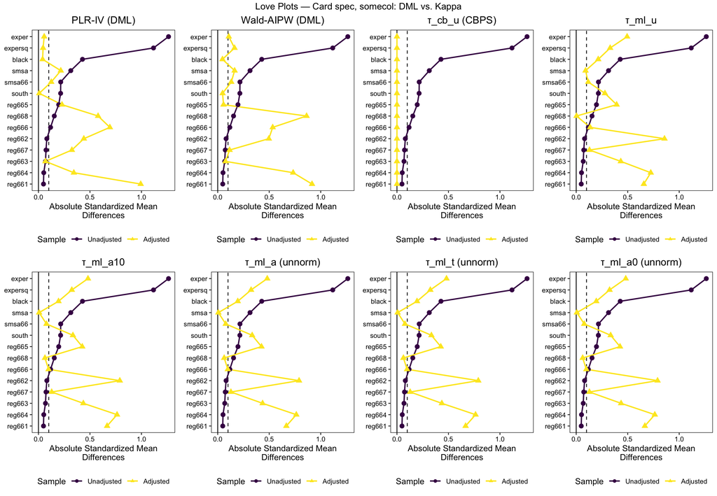

```r
lp_d1 <- list(
  make_love("PLR-IV (DML)",     w_card_d1$plriv,     D1, X_dml_card),
  make_love("Wald-AIPW (DML)",  w_card_d1$waldaipw,  D1, X_dml_card),
  make_love("τ_cb_u (CBPS)",    kw_card_d1$tau_cb_u, D1, X_dml_card),
  make_love("τ_ml_u",           kw_card_d1$tau_ml_u, D1, X_dml_card),
  make_love("τ_ml_a10",         kw_card_d1$tau_ml_a10, D1, X_dml_card),
  make_love("τ_ml_a (unnorm)",  kw_card_d1$tau_ml_a, D1, X_dml_card),
  make_love("τ_ml_t (unnorm)",  kw_card_d1$tau_ml_a1, D1, X_dml_card),
  make_love("τ_ml_a0 (unnorm)", kw_card_d1$tau_ml_a0, D1, X_dml_card)
)
grid.arrange(grobs = lp_d1, nrow = 2,
             top = "Love Plots — Card spec, somecol: DML vs. Kappa")
```

### Card spec — educ16 (all 8 estimators)

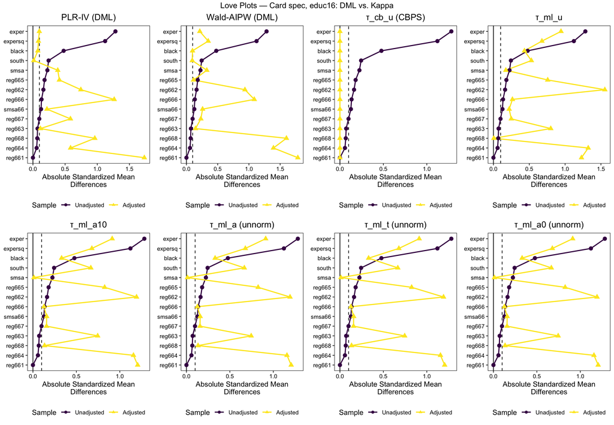

```r
lp_d2 <- list(
  make_love("PLR-IV (DML)",     w_card_d2$plriv,     D2, X_dml_card),
  make_love("Wald-AIPW (DML)",  w_card_d2$waldaipw,  D2, X_dml_card),
  make_love("τ_cb_u (CBPS)",    kw_card_d2$tau_cb_u, D2, X_dml_card),
  make_love("τ_ml_u",           kw_card_d2$tau_ml_u, D2, X_dml_card),
  make_love("τ_ml_a10",         kw_card_d2$tau_ml_a10, D2, X_dml_card),
  make_love("τ_ml_a (unnorm)",  kw_card_d2$tau_ml_a, D2, X_dml_card),
  make_love("τ_ml_t (unnorm)",  kw_card_d2$tau_ml_a1, D2, X_dml_card),
  make_love("τ_ml_a0 (unnorm)", kw_card_d2$tau_ml_a0, D2, X_dml_card)
)
grid.arrange(grobs = lp_d2, nrow = 2,
             top = "Love Plots — Card spec, educ16: DML vs. Kappa")
```

### DML only — Card vs. Kitagawa (somecol)

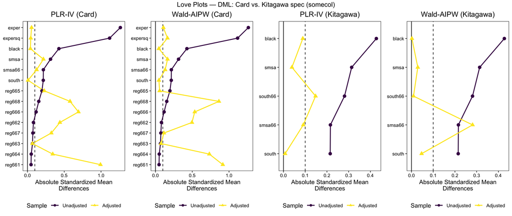

```r
lp_cmp <- list(
  make_love("PLR-IV (Card)",        w_card_d1$plriv,    D1, X_dml_card),
  make_love("Wald-AIPW (Card)",     w_card_d1$waldaipw, D1, X_dml_card),
  make_love("PLR-IV (Kitagawa)",    w_kit_d1$plriv,     D1, X_dml_kit),
  make_love("Wald-AIPW (Kitagawa)", w_kit_d1$waldaipw,  D1, X_dml_kit)
)
grid.arrange(grobs = lp_cmp, nrow = 1,
             top = "Love Plots — DML: Card vs. Kitagawa spec (somecol)")
```

*End of Card framework presentation (kappa replication + DML extension).*  
*All functions sourced from `functions_all.R`. No estimation function defined inline — only thin table/plot-display wrappers.*

# Part VI — DoubleML Learner Comparison (Linear / Ranger / XGBoost)

**Setup.** Three learners via `DoubleMLIIVM` (dev version of OutcomeWeights required for `get_outcome_weights()` on R6 objects), 5-fold cross-fitting, `score = "LATE"`. Each learner is fit on all **4 cells** (Card / Kitagawa × somecol / educ16) — 12 IIVM fits total. Learners: (1) linear + logistic (parametric baseline), (2) ranger random forest (`keep.inbag = TRUE`, required for the affine smoother identity), (3) XGBoost with the affine-smoother hyperparameters (`alpha=0, subsample=1, max_delta_step=0, base_score=0` on the regression learner). The identity $\sum_i \omega_i Y_i = \hat\tau$ is checked for each — XGBoost may fail it under XGBoost ≥ 1.6 due to the `base_score` change.

```r
library(DoubleML)
library(mlr3verse)

# Small SE accessor for DoubleMLIIVM summary (the only helper not in
# functions_all.R). Everything else — get_dml_coef, check_doubleml_identity,
# doubleml_translation_row, make_X, kappa_weights_bundle, make_love, weight_diag
# — is sourced from functions_all.R.
get_dml_se <- function(obj) {
  s <- obj$summary()
  if ("std err"    %in% colnames(s)) return(as.numeric(s[1, "std err"]))
  if ("Std. Error" %in% colnames(s)) return(as.numeric(s[1, "Std. Error"]))
  NA_real_
}

# DoubleMLData objects — one per cell. d and z must be numeric 0/1.
make_dml_data <- function(D, X_dml) {
  df <- as.data.frame(X_dml)
  df$y <- as.numeric(Y_dol)
  df$d <- as.numeric(D)
  df$z <- as.numeric(Z)
  DoubleMLData$new(data = df, y_col = "y", d_cols = "d", z_cols = "z",
                   x_cols = colnames(X_dml))
}

dat_card_d1 <- make_dml_data(D1, X_dml_card)
dat_card_d2 <- make_dml_data(D2, X_dml_card)
dat_kit_d1  <- make_dml_data(D1, X_dml_kit)
dat_kit_d2  <- make_dml_data(D2, X_dml_kit)

cat("DoubleML data objects built for all 4 cells.\n")
```

```
## DoubleML data objects built for all 4 cells.
```

## Estimation — 3 Learners × 4 Cells

### Linear + Logistic

```r
lm_card_d1 <- fit_iivm(dat_card_d1, ml_lm(), Y_dol)
lm_card_d2 <- fit_iivm(dat_card_d2, ml_lm(), Y_dol)
lm_kit_d1  <- fit_iivm(dat_kit_d1,  ml_lm(), Y_dol)
lm_kit_d2  <- fit_iivm(dat_kit_d2,  ml_lm(), Y_dol)

data.frame(
  Cell        = c("Card / somecol","Card / educ16","Kitagawa / somecol","Kitagawa / educ16"),
  Estimate    = round(c(get_dml_coef(lm_card_d1$obj), get_dml_coef(lm_card_d2$obj),
                        get_dml_coef(lm_kit_d1$obj),  get_dml_coef(lm_kit_d2$obj)), 4),
  SE          = round(c(get_dml_se(lm_card_d1$obj), get_dml_se(lm_card_d2$obj),
                        get_dml_se(lm_kit_d1$obj),  get_dml_se(lm_kit_d2$obj)), 4),
  `ΣωY = τ̂` = c(lm_card_d1$ok, lm_card_d2$ok, lm_kit_d1$ok, lm_kit_d2$ok),
  check.names = FALSE
) %>%
  kbl(caption = "Wald-AIPW — Linear + Logistic (all 4 cells)",
      align = c("l","r","r","c")) %>%
  kable_styling(bootstrap_options = c("striped","hover","condensed"),
                full_width = FALSE, font_size = 13) %>%
  footnote(general = "ΣωY = τ̂: algebraic identity check (must be TRUE).")
```

```
## Estimates and significance testing of the effect of target variables
##   Estimate. Std. Error t value Pr(>|t|)
## d    0.3991     0.2483   1.608    0.108
##
##
## Estimates and significance testing of the effect of target variables
##   Estimate. Std. Error t value Pr(>|t|)
## d    0.8843     0.6079   1.455    0.146
##
##
## Estimates and significance testing of the effect of target variables
##   Estimate. Std. Error t value Pr(>|t|)
## d    0.3112     0.2351   1.324    0.186
##
##
## Estimates and significance testing of the effect of target variables
##   Estimate. Std. Error t value Pr(>|t|)
## d    0.5336     0.4092   1.304    0.192
```

Wald-AIPW — Linear + Logistic (all 4 cells)

| Cell | Estimate | SE | ΣωY = τ̂ |
| --- | --- | --- | --- |
| Card / somecol | 0.3991 | 0.2483 | TRUE |
| Card / educ16 | 0.8843 | 0.6079 | TRUE |
| Kitagawa / somecol | 0.3112 | 0.2351 | TRUE |
| Kitagawa / educ16 | 0.5336 | 0.4092 | TRUE |

Note:  
ΣωY = τ̂: algebraic identity check (must be TRUE).

### Ranger

```r
rf_card_d1 <- fit_iivm(dat_card_d1, ml_rf(), Y_dol)
rf_card_d2 <- fit_iivm(dat_card_d2, ml_rf(), Y_dol)
rf_kit_d1  <- fit_iivm(dat_kit_d1,  ml_rf(), Y_dol)
rf_kit_d2  <- fit_iivm(dat_kit_d2,  ml_rf(), Y_dol)

data.frame(
  Cell        = c("Card / somecol","Card / educ16","Kitagawa / somecol","Kitagawa / educ16"),
  Estimate    = round(c(get_dml_coef(rf_card_d1$obj), get_dml_coef(rf_card_d2$obj),
                        get_dml_coef(rf_kit_d1$obj),  get_dml_coef(rf_kit_d2$obj)), 4),
  SE          = round(c(get_dml_se(rf_card_d1$obj), get_dml_se(rf_card_d2$obj),
                        get_dml_se(rf_kit_d1$obj),  get_dml_se(rf_kit_d2$obj)), 4),
  `ΣωY = τ̂` = c(rf_card_d1$ok, rf_card_d2$ok, rf_kit_d1$ok, rf_kit_d2$ok),
  check.names = FALSE
) %>%
  kbl(caption = "Wald-AIPW — Ranger (all 4 cells)",
      align = c("l","r","r","c")) %>%
  kable_styling(bootstrap_options = c("striped","hover","condensed"),
                full_width = FALSE, font_size = 13) %>%
  footnote(general = "ΣωY = τ̂: algebraic identity check (must be TRUE).")
```

```
## Estimates and significance testing of the effect of target variables
##   Estimate. Std. Error t value Pr(>|t|)
## d    0.2621     0.1948   1.345    0.179
##
##
## Estimates and significance testing of the effect of target variables
##   Estimate. Std. Error t value Pr(>|t|)
## d    0.4926     0.3751   1.313    0.189
##
##
## Estimates and significance testing of the effect of target variables
##   Estimate. Std. Error t value Pr(>|t|)
## d    0.2943     0.2310   1.274    0.203
##
##
## Estimates and significance testing of the effect of target variables
##   Estimate. Std. Error t value Pr(>|t|)
## d    0.5142     0.4084   1.259    0.208
```

Wald-AIPW — Ranger (all 4 cells)

| Cell | Estimate | SE | ΣωY = τ̂ |
| --- | --- | --- | --- |
| Card / somecol | 0.2621 | 0.1948 | TRUE |
| Card / educ16 | 0.4926 | 0.3751 | TRUE |
| Kitagawa / somecol | 0.2943 | 0.2310 | TRUE |
| Kitagawa / educ16 | 0.5142 | 0.4084 | TRUE |

Note:  
ΣωY = τ̂: algebraic identity check (must be TRUE).

### XGBoost

```r
xgb_card_d1 <- fit_iivm(dat_card_d1, ml_xgb(), Y_dol)
xgb_card_d2 <- fit_iivm(dat_card_d2, ml_xgb(), Y_dol)
xgb_kit_d1  <- fit_iivm(dat_kit_d1,  ml_xgb(), Y_dol)
xgb_kit_d2  <- fit_iivm(dat_kit_d2,  ml_xgb(), Y_dol)

data.frame(
  Cell        = c("Card / somecol","Card / educ16","Kitagawa / somecol","Kitagawa / educ16"),
  Estimate    = round(c(get_dml_coef(xgb_card_d1$obj), get_dml_coef(xgb_card_d2$obj),
                        get_dml_coef(xgb_kit_d1$obj),  get_dml_coef(xgb_kit_d2$obj)), 4),
  SE          = round(c(get_dml_se(xgb_card_d1$obj), get_dml_se(xgb_card_d2$obj),
                        get_dml_se(xgb_kit_d1$obj),  get_dml_se(xgb_kit_d2$obj)), 4),
  `ΣωY = τ̂` = c(xgb_card_d1$ok, xgb_card_d2$ok, xgb_kit_d1$ok, xgb_kit_d2$ok),
  check.names = FALSE
) %>%
  kbl(caption = "Wald-AIPW — XGBoost (all 4 cells)",
      align = c("l","r","r","c")) %>%
  kable_styling(bootstrap_options = c("striped","hover","condensed"),
                full_width = FALSE, font_size = 13) %>%
  footnote(general = "ΣωY = τ̂: algebraic identity check. May read FALSE for XGBoost ≥ 1.6 due to the base_score change (non-affine smoother).")
```

```
## Estimates and significance testing of the effect of target variables
##   Estimate. Std. Error t value Pr(>|t|)
## d    -13.42      14.41  -0.931    0.352
##
##
## Estimates and significance testing of the effect of target variables
##   Estimate. Std. Error t value Pr(>|t|)
## d    -3.198      4.054  -0.789     0.43
##
##
## Estimates and significance testing of the effect of target variables
##   Estimate. Std. Error t value Pr(>|t|)
## d   -0.1134     0.6271  -0.181    0.857
##
##
## Estimates and significance testing of the effect of target variables
##   Estimate. Std. Error t value Pr(>|t|)
## d    -3.656    100.914  -0.036    0.971
```

Wald-AIPW — XGBoost (all 4 cells)

| Cell | Estimate | SE | ΣωY = τ̂ |
| --- | --- | --- | --- |
| Card / somecol | -13.4155 | 14.4111 | FALSE |
| Card / educ16 | -3.1980 | 4.0540 | FALSE |
| Kitagawa / somecol | -0.1134 | 0.6271 | FALSE |
| Kitagawa / educ16 | -3.6561 | 100.9143 | FALSE |

Note:  
ΣωY = τ̂: algebraic identity check. May read FALSE for XGBoost ≥ 1.6 due to the base_score change (non-affine smoother).

**Note on XGBoost.** The algebraic identity $\sum_i \omega_i Y_i = \hat\tau$ may fail for XGBoost because of a change in `base_score` behaviour in XGBoost ≥ 1.6, which breaks the affine smoother condition (Knaus & Rakov). Ranger is recommended for standard use; XGBoost results should be flagged where the identity does not hold.

## Learner Comparison Table

```r
ext_cell <- function(coef, se) {
  if (is.na(coef) || !is.finite(coef)) return("—")
  if (is.na(se) || !is.finite(se) || se <= 0) return(sprintf("%.3f (NA)", coef))
  pval  <- 2 * pnorm(-abs(coef / se))
  stars <- ifelse(pval < 0.01, "***", ifelse(pval < 0.05, "**",
                  ifelse(pval < 0.10, "*", "")))
  sprintf("%.3f%s (%.3f)", coef, stars, se)
}

learner_row <- function(label, f_card_d1, f_kit_d1, f_card_d2, f_kit_d2) {
  data.frame(
    Estimator = label,
    `somecol / Card`     = ext_cell(get_dml_coef(f_card_d1$obj), get_dml_se(f_card_d1$obj)),
    `somecol / Kitagawa` = ext_cell(get_dml_coef(f_kit_d1$obj),  get_dml_se(f_kit_d1$obj)),
    `educ16 / Card`      = ext_cell(get_dml_coef(f_card_d2$obj), get_dml_se(f_card_d2$obj)),
    `educ16 / Kitagawa`  = ext_cell(get_dml_coef(f_kit_d2$obj),  get_dml_se(f_kit_d2$obj)),
    check.names = FALSE, stringsAsFactors = FALSE
  )
}

# Kappa reference rows (tau_cb_u, tau_ml_u) for context
kappa_ref_row <- function(label, key) {
  data.frame(
    Estimator = label,
    `somecol / Card`     = ext_cell(kappa_card_d1$estimates[key], kappa_card_d1$se[key]),
    `somecol / Kitagawa` = ext_cell(kappa_kit_d1$estimates[key],  kappa_kit_d1$se[key]),
    `educ16 / Card`      = ext_cell(kappa_card_d2$estimates[key], kappa_card_d2$se[key]),
    `educ16 / Kitagawa`  = ext_cell(kappa_kit_d2$estimates[key],  kappa_kit_d2$se[key]),
    check.names = FALSE, stringsAsFactors = FALSE
  )
}

ext_tbl <- rbind(
  learner_row("Wald-AIPW (linear+logit)", lm_card_d1,  lm_kit_d1,  lm_card_d2,  lm_kit_d2),
  learner_row("Wald-AIPW (ranger)",       rf_card_d1,  rf_kit_d1,  rf_card_d2,  rf_kit_d2),
  learner_row("Wald-AIPW (XGBoost)",      xgb_card_d1, xgb_kit_d1, xgb_card_d2, xgb_kit_d2),
  kappa_ref_row("τ_cb_u (kappa, ref)",  "tau_cb_u"),
  kappa_ref_row("τ_ml_u (kappa, ref)",  "tau_ml_u")
)
```

```
## Estimates and significance testing of the effect of target variables
##   Estimate. Std. Error t value Pr(>|t|)
## d    0.3991     0.2483   1.608    0.108
##
##
## Estimates and significance testing of the effect of target variables
##   Estimate. Std. Error t value Pr(>|t|)
## d    0.3112     0.2351   1.324    0.186
##
##
## Estimates and significance testing of the effect of target variables
##   Estimate. Std. Error t value Pr(>|t|)
## d    0.8843     0.6079   1.455    0.146
##
##
## Estimates and significance testing of the effect of target variables
##   Estimate. Std. Error t value Pr(>|t|)
## d    0.5336     0.4092   1.304    0.192
##
##
## Estimates and significance testing of the effect of target variables
##   Estimate. Std. Error t value Pr(>|t|)
## d    0.2621     0.1948   1.345    0.179
##
##
## Estimates and significance testing of the effect of target variables
##   Estimate. Std. Error t value Pr(>|t|)
## d    0.2943     0.2310   1.274    0.203
##
##
## Estimates and significance testing of the effect of target variables
##   Estimate. Std. Error t value Pr(>|t|)
## d    0.4926     0.3751   1.313    0.189
##
##
## Estimates and significance testing of the effect of target variables
##   Estimate. Std. Error t value Pr(>|t|)
## d    0.5142     0.4084   1.259    0.208
##
##
## Estimates and significance testing of the effect of target variables
##   Estimate. Std. Error t value Pr(>|t|)
## d    -13.42      14.41  -0.931    0.352
##
##
## Estimates and significance testing of the effect of target variables
##   Estimate. Std. Error t value Pr(>|t|)
## d   -0.1134     0.6271  -0.181    0.857
##
##
## Estimates and significance testing of the effect of target variables
##   Estimate. Std. Error t value Pr(>|t|)
## d    -3.198      4.054  -0.789     0.43
##
##
## Estimates and significance testing of the effect of target variables
##   Estimate. Std. Error t value Pr(>|t|)
## d    -3.656    100.914  -0.036    0.971
```

```r
ext_tbl %>%
  kbl(align = c("l","c","c","c","c"),
      caption = "Wald-AIPW Learner Comparison — DoubleML vs. Kappa (Y = log wages, dollars)") %>%
  kable_styling(bootstrap_options = c("striped","hover","condensed"),
                full_width = TRUE, font_size = 13) %>%
  pack_rows("DoubleML learners", 1, 3) %>%
  pack_rows("Kappa reference",   4, 5) %>%
  row_spec(1:3, background = "#eef6ff") %>%
  footnote(general = "Each cell: estimate (SE). Blue = DoubleML. All score='LATE', n_folds=5. Stars: * p<0.10, ** p<0.05, *** p<0.01.")
```

Wald-AIPW Learner Comparison — DoubleML vs. Kappa (Y = log wages, dollars)

| Estimator | somecol / Card | somecol / Kitagawa | educ16 / Card | educ16 / Kitagawa |
| --- | --- | --- | --- | --- |
| **DoubleML learners** |  |  |  |  |
| Wald-AIPW (linear+logit) | 0.399 (0.248) | 0.311 (0.235) | 0.884 (0.608) | 0.534 (0.409) |
| Wald-AIPW (ranger) | 0.262 (0.195) | 0.294 (0.231) | 0.493 (0.375) | 0.514 (0.408) |
| Wald-AIPW (XGBoost) | -13.416 (14.411) | -0.113 (0.627) | -3.198 (4.054) | -3.656 (100.914) |
| **Kappa reference** |  |  |  |  |
| τ_cb_u (kappa, ref) | 0.376* (0.223) | 0.331 (0.236) | 0.853 (0.549) | 0.588 (0.433) |
| τ_ml_u (kappa, ref) | 0.331 (0.202) | 0.356 (0.244) | 0.619 (0.387) | 0.628 (0.448) |

Note:  
Each cell: estimate (SE). Blue = DoubleML. All score=‘LATE’, n_folds=5. Stars: * p<0.10, ** p<0.05, *** p<0.01.

## Translation Invariance — Learners vs. Kappa

### Card — somecol

```r
style_ext_ti(ext_ti_block(D1, X_card_kappa, lm_card_d1$w, rf_card_d1$w, xgb_card_d1$w),
             "Translation Invariance — Card, somecol")
```

Translation Invariance — Card, somecol

| Estimator | Dollars | Cents | Diff_actual | Diff_pred | Match |
| --- | --- | --- | --- | --- | --- |
| Wald-AIPW (linear+logit) | 0.3991 | 0.3991 | 0.000000 | 0.000000 | TRUE |
| Wald-AIPW (ranger) | 0.2621 | 0.2621 | 0.000000 | 0.000000 | TRUE |
| Wald-AIPW (XGBoost) | -13.4155 | -19.3134 | -5.897860 | -5.897860 | TRUE |
| τ_cb_u (kappa) | 0.3762 | 0.3762 | 0.000000 | 0.000000 | TRUE |
| τ_ml_u (kappa) | 0.3308 | 0.3308 | 0.000000 | 0.000000 | TRUE |
| τ_ml_a (unnorm) | 0.1695 | -0.3193 | -0.488839 | -0.488839 | TRUE |
| τ_ml_t (unnorm) | 0.1707 | -0.3214 | -0.492106 | -0.492106 | TRUE |
| τ_ml_a0 (unnorm) | 0.1542 | -0.2904 | -0.444597 | -0.444597 | TRUE |

Note:  
Diff_actual = Cents − Dollars. Diff_pred = Σωᵢ × log(100). Green = translation invariant. Bold = DoubleML learners.

### Card — educ16

```r
style_ext_ti(ext_ti_block(D2, X_card_kappa, lm_card_d2$w, rf_card_d2$w, xgb_card_d2$w),
             "Translation Invariance — Card, educ16")
```

Translation Invariance — Card, educ16

| Estimator | Dollars | Cents | Diff_actual | Diff_pred | Match |
| --- | --- | --- | --- | --- | --- |
| Wald-AIPW (linear+logit) | 0.8843 | 0.8843 | 0.000000 | 0.000000 | TRUE |
| Wald-AIPW (ranger) | 0.4926 | 0.4926 | 0.000000 | 0.000000 | TRUE |
| Wald-AIPW (XGBoost) | -3.1980 | -4.6040 | -1.405954 | -1.405954 | TRUE |
| τ_cb_u (kappa) | 0.8530 | 0.8530 | 0.000000 | 0.000000 | TRUE |
| τ_ml_u (kappa) | 0.6191 | 0.6191 | 0.000000 | 0.000000 | TRUE |
| τ_ml_a (unnorm) | 0.3154 | -0.5939 | -0.909273 | -0.909273 | TRUE |
| τ_ml_t (unnorm) | 0.3193 | -0.6013 | -0.920642 | -0.920642 | TRUE |
| τ_ml_a0 (unnorm) | 0.2661 | -0.5012 | -0.767256 | -0.767256 | TRUE |

Note:  
Diff_actual = Cents − Dollars. Diff_pred = Σωᵢ × log(100). Green = translation invariant. Bold = DoubleML learners.

### Kitagawa — somecol

```r
style_ext_ti(ext_ti_block(D1, X_kit_kappa, lm_kit_d1$w, rf_kit_d1$w, xgb_kit_d1$w),
             "Translation Invariance — Kitagawa, somecol")
```

Translation Invariance — Kitagawa, somecol

| Estimator | Dollars | Cents | Diff_actual | Diff_pred | Match |
| --- | --- | --- | --- | --- | --- |
| Wald-AIPW (linear+logit) | 0.3112 | 0.3112 | 0.000000 | 0.000000 | TRUE |
| Wald-AIPW (ranger) | 0.2943 | 0.2943 | 0.000000 | 0.000000 | TRUE |
| Wald-AIPW (XGBoost) | -0.1134 | -0.3984 | -0.284998 | -0.284998 | TRUE |
| τ_cb_u (kappa) | 0.3310 | 0.3310 | 0.000000 | 0.000000 | TRUE |
| τ_ml_u (kappa) | 0.3556 | 0.3556 | 0.000000 | 0.000000 | TRUE |
| τ_ml_a (unnorm) | 0.8418 | 2.2476 | 1.405803 | 1.405803 | TRUE |
| τ_ml_t (unnorm) | 0.7688 | 2.0526 | 1.283819 | 1.283819 | TRUE |
| τ_ml_a0 (unnorm) | 1.0659 | 2.8460 | 1.780059 | 1.780059 | TRUE |

Note:  
Diff_actual = Cents − Dollars. Diff_pred = Σωᵢ × log(100). Green = translation invariant. Bold = DoubleML learners.

### Kitagawa — educ16

```r
style_ext_ti(ext_ti_block(D2, X_kit_kappa, lm_kit_d2$w, rf_kit_d2$w, xgb_kit_d2$w),
             "Translation Invariance — Kitagawa, educ16")
```

Translation Invariance — Kitagawa, educ16

[output not shown]

Note:  
Diff_actual = Cents − Dollars. Diff_pred = Σωᵢ × log(100). Green = translation invariant. Bold = DoubleML learners.

## Weight Diagnostics — All Learners × 4 Cells

**Reading the table.** `Sum_w ≈ 0` confirms translation invariance. `ESS = 1/Σωᵢ²` — compare across learners (do ranger and XGBoost diverge?) and across specs (does the richer Card spec lower ESS vs. Kitagawa?). `Pct_neg`, `Max_abs_w` flag weight concentration.

### Card — somecol

```r
style_ext_diag(ext_diag_block(D1, X_card_kappa, lm_card_d1$w, rf_card_d1$w, xgb_card_d1$w),
               "Weight Diagnostics — Card, somecol")
```

Weight Diagnostics — Card, somecol

| Estimator | Sum_w | ESS | Pct_neg | Max_abs_w |
| --- | --- | --- | --- | --- |
| Wald-AIPW (linear+logit) | 0.0000000 | 3 | 31.6 | 0.080896 |
| Wald-AIPW (ranger) | 0.0000000 | 3 | 31.8 | 0.135400 |
| Wald-AIPW (XGBoost) | -1.2807040 | 0 | 57.0 | 20.028391 |
| τ_cb_u (kappa, CBPS) | 0.0000000 | 3 | 31.8 | 0.086905 |
| τ_ml_u (kappa, MLE) | 0.0000000 | 4 | 31.8 | 0.051920 |
| τ_ml_a10 (kappa, MLE) | 0.0000000 | 4 | 31.8 | 0.054816 |
| τ_ml_a (kappa, unnorm) | -0.1061501 | 3 | 31.8 | 0.054452 |
| τ_ml_t (kappa, unnorm) | -0.1068595 | 3 | 31.8 | 0.054816 |
| τ_ml_a0 (kappa, unnorm) | -0.0965429 | 4 | 31.8 | 0.049524 |

Note:  
Blue = DoubleML learners. Sum_w ≈ 0 ⟺ translation invariant. ESS = 1/Σωᵢ².

### Card — educ16

```r
style_ext_diag(ext_diag_block(D2, X_card_kappa, lm_card_d2$w, rf_card_d2$w, xgb_card_d2$w),
               "Weight Diagnostics — Card, educ16")
```

Weight Diagnostics — Card, educ16

| Estimator | Sum_w | ESS | Pct_neg | Max_abs_w |
| --- | --- | --- | --- | --- |
| Wald-AIPW (linear+logit) | 0.0000000 | 1 | 31.6 | 0.179228 |
| Wald-AIPW (ranger) | 0.0000000 | 1 | 31.8 | 0.254498 |
| Wald-AIPW (XGBoost) | -0.3052991 | 0 | 57.0 | 4.774444 |
| τ_cb_u (kappa, CBPS) | 0.0000000 | 1 | 31.8 | 0.197058 |
| τ_ml_u (kappa, MLE) | 0.0000000 | 1 | 31.8 | 0.097168 |
| τ_ml_a10 (kappa, MLE) | 0.0000000 | 1 | 31.8 | 0.102551 |
| τ_ml_a (kappa, unnorm) | -0.1974461 | 1 | 31.8 | 0.101285 |
| τ_ml_t (kappa, unnorm) | -0.1999148 | 1 | 31.8 | 0.102551 |
| τ_ml_a0 (kappa, unnorm) | -0.1666075 | 1 | 31.8 | 0.085466 |

Note:  
Blue = DoubleML learners. Sum_w ≈ 0 ⟺ translation invariant. ESS = 1/Σωᵢ².

### Kitagawa — somecol

```r
style_ext_diag(ext_diag_block(D1, X_kit_kappa, lm_kit_d1$w, rf_kit_d1$w, xgb_kit_d1$w),
               "Weight Diagnostics — Kitagawa, somecol")
```

Weight Diagnostics — Kitagawa, somecol

| Estimator | Sum_w | ESS | Pct_neg | Max_abs_w |
| --- | --- | --- | --- | --- |
| Wald-AIPW (linear+logit) | 0.0000000 | 3 | 31.8 | 0.048008 |
| Wald-AIPW (ranger) | 0.0000000 | 3 | 31.8 | 0.056832 |
| Wald-AIPW (XGBoost) | -0.0618865 | 1 | 31.5 | 0.683368 |
| τ_cb_u (kappa, CBPS) | 0.0000000 | 3 | 31.8 | 0.045670 |
| τ_ml_u (kappa, MLE) | 0.0000000 | 3 | 31.8 | 0.044385 |
| τ_ml_a10 (kappa, MLE) | 0.0000000 | 3 | 31.8 | 0.052601 |
| τ_ml_a (kappa, unnorm) | 0.3052662 | 3 | 31.8 | 0.041541 |
| τ_ml_t (kappa, unnorm) | 0.2787776 | 4 | 31.8 | 0.037937 |
| τ_ml_a0 (kappa, unnorm) | 0.3865350 | 2 | 31.8 | 0.052601 |

Note:  
Blue = DoubleML learners. Sum_w ≈ 0 ⟺ translation invariant. ESS = 1/Σωᵢ².

### Kitagawa — educ16

```r
style_ext_diag(ext_diag_block(D2, X_kit_kappa, lm_kit_d2$w, rf_kit_d2$w, xgb_kit_d2$w),
               "Weight Diagnostics — Kitagawa, educ16")
```

Weight Diagnostics — Kitagawa, educ16

| Estimator | Sum_w | ESS | Pct_neg | Max_abs_w |
| --- | --- | --- | --- | --- |
| Wald-AIPW (linear+logit) | 0.0000000 | 1 | 31.8 | 0.082312 |
| Wald-AIPW (ranger) | 0.0000000 | 1 | 31.8 | 0.099308 |
| Wald-AIPW (XGBoost) | -1.9959090 | 0 | 31.5 | 22.039408 |
| τ_cb_u (kappa, CBPS) | 0.0000000 | 1 | 31.8 | 0.081202 |
| τ_ml_u (kappa, MLE) | 0.0000000 | 1 | 31.8 | 0.078334 |
| τ_ml_a10 (kappa, MLE) | 0.0000000 | 0 | 31.8 | 0.133832 |
| τ_ml_a (kappa, unnorm) | 0.5863184 | 1 | 31.8 | 0.079788 |
| τ_ml_t (kappa, unnorm) | 0.4958309 | 1 | 31.8 | 0.067474 |
| τ_ml_a0 (kappa, unnorm) | 0.9834616 | 0 | 31.8 | 0.133832 |

Note:  
Blue = DoubleML learners. Sum_w ≈ 0 ⟺ translation invariant. ESS = 1/Σωᵢ².

## Love Plots — Learner Comparison

### Card — somecol (3 learners + 2 kappa)

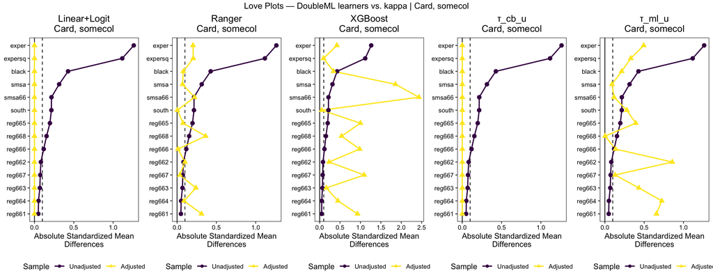

```r
kw_card_d1 <- kappa_weights_bundle(Z, D1, X_card_kappa)
lp1 <- list(
  make_love("Linear+Logit\nCard, somecol",  lm_card_d1$w,        D1, X_dml_card),
  make_love("Ranger\nCard, somecol",        rf_card_d1$w,        D1, X_dml_card),
  make_love("XGBoost\nCard, somecol",       xgb_card_d1$w,       D1, X_dml_card),
  make_love("τ_cb_u\nCard, somecol",        kw_card_d1$tau_cb_u, D1, X_dml_card),
  make_love("τ_ml_u\nCard, somecol",        kw_card_d1$tau_ml_u, D1, X_dml_card)
)
grid.arrange(grobs = lp1, nrow = 1,
             top = "Love Plots — DoubleML learners vs. kappa | Card, somecol")
```

### Card — educ16 (3 learners + 2 kappa)

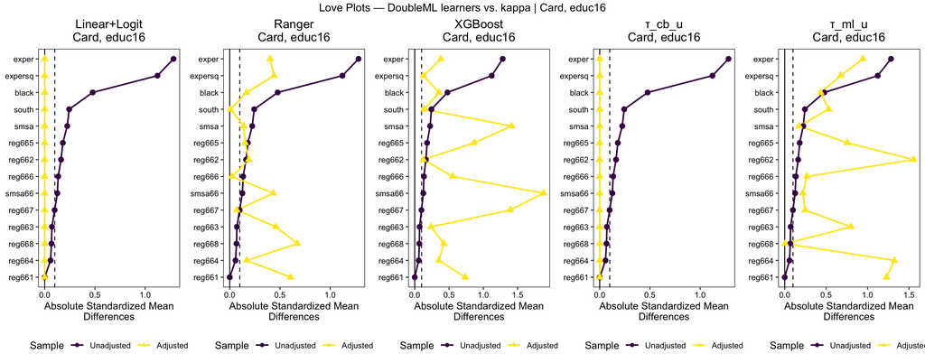

```r
kw_card_d2 <- kappa_weights_bundle(Z, D2, X_card_kappa)
lp2 <- list(
  make_love("Linear+Logit\nCard, educ16",   lm_card_d2$w,        D2, X_dml_card),
  make_love("Ranger\nCard, educ16",         rf_card_d2$w,        D2, X_dml_card),
  make_love("XGBoost\nCard, educ16",        xgb_card_d2$w,       D2, X_dml_card),
  make_love("τ_cb_u\nCard, educ16",         kw_card_d2$tau_cb_u, D2, X_dml_card),
  make_love("τ_ml_u\nCard, educ16",         kw_card_d2$tau_ml_u, D2, X_dml_card)
)
grid.arrange(grobs = lp2, nrow = 1,
             top = "Love Plots — DoubleML learners vs. kappa | Card, educ16")
```

### Spec Comparison — Card vs. Kitagawa (somecol)

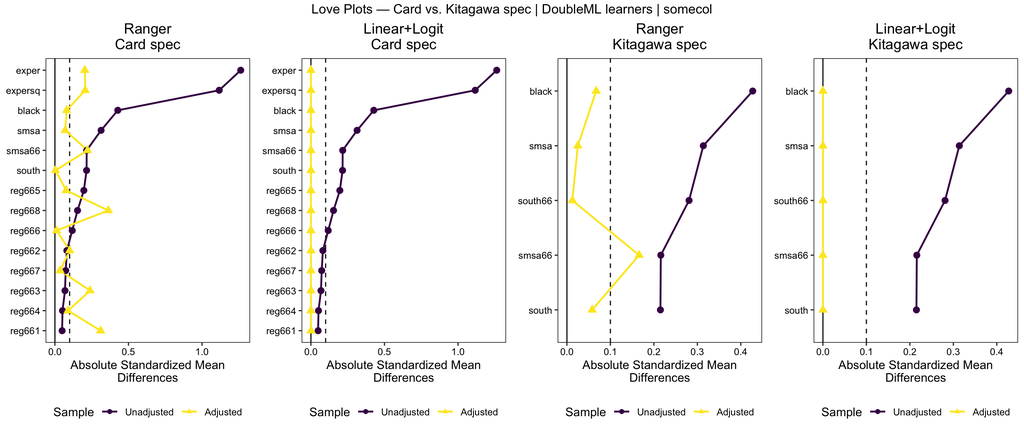

```r
lp3 <- list(
  make_love("Ranger\nCard spec",        rf_card_d1$w, D1, X_dml_card),
  make_love("Linear+Logit\nCard spec",  lm_card_d1$w, D1, X_dml_card),
  make_love("Ranger\nKitagawa spec",    rf_kit_d1$w,  D1, X_dml_kit),
  make_love("Linear+Logit\nKitagawa spec", lm_kit_d1$w, D1, X_dml_kit)
)
grid.arrange(grobs = lp3, nrow = 1,
             top = "Love Plots — Card vs. Kitagawa spec | DoubleML learners | somecol")
```

*End of Card framework presentation (kappa replication + DML + learner comparison).*  
*All functions sourced from `functions_all.R`; only `get_dml_se` and thin table/plot wrappers are defined inline.*